# Kapitola 14: Naive Bayes Classification

Bayes Rules! An Introduction to Applied Bayesian Modeling

Podla Johnson, Ott, Dogucu

2025-12-03

# 1 Uvod

V Antarktide existuje viacero druhov tucniakov, vratane Adelie, Chinstrap a Gentoo. Pri stretnutí s jednym z tychto tucniakov mozeme klasifikovat jeho druh

$$Y = \begin{cases} A & \text{ Adelie}
\\ C & \text{ Chinstrap} \\ G & \text{ Gentoo}
\end{cases}$$

na zaklade roznych fyzickych charakteristik, napriklad ci tucniak vazi viac ako priemerna vaha 4200g:

$$X_{1} = \begin{cases} 1 & \text{
nadpriemerna vaha} \\ 0 & \text{ podpriemerna vaha}
\end{cases}$$

ako aj merania zobaka tucniaka:

$$\begin{split}
X_{2} & = \text{ dlzka zobaka (v mm)} \\
X_{3} & = \text{ dlzka plutvy (v mm)}
\end{split}$$

## 1.1 Nacitanie dat a kniznic

```r
# Nacitanie potrebnych balikov
library(bayesrules)
library(tidyverse)
library(e1071)
library(janitor)

# Nacitanie dat
data(penguins_bayes)
penguins <- penguins_bayes
```

## 1.2 Prehlad dat

```r
# Rozdelenie tucniakov podla druhov
penguins %>%
  tabyl(species)
```

```
##    species   n   percent
##     Adelie 152 0.4418605
##  Chinstrap  68 0.1976744
##     Gentoo 124 0.3604651
```

Medzi tymito tucniakmi je 152 Adelie, 68 Chinstrap a 124 Gentoo. Nase **apriorné predpoklady** o akomkolvek novom tucniakovi su, ze je najpravdepodobnejsie Adelie a najmenej pravdepodobne Chinstrap.

## 1.3 Preco potrebujeme Naive Bayes?

**Otazka**: Preco ani normalny regresny model ani logisticka regresia nie su vhodne na klasifikaciu druhu tucniaka $Y$ podla jeho fyzickych charakteristik $X$?

**Odpoved**:

- Kedze druh $Y$ je kategoricka premenna, **normalna regresia nie je vhodna** na pochopenie jej vztahu s fyzickymi charakteristikami $X$.
- Hoci logisticka regresia je nastroj na modelovanie kategorickych odpovedi, **je limitovana na binarne odpovedne premenne** (Bernoulliho struktura dat).
- Nasa premenna druhu $Y$ ma **tri kategorie**.

**Vyhody Naive Bayes klasifikacie** oproti Bayesovskej logistickej regresii:

1. Moze klasifikovat kategoricke odpovedne premenne s **dvoma alebo viac kategoriami**
2. Nevyzaduje vela teorie okrem **Bayesovho pravidla**
3. Je **vypoctovo efektivna** (nevyzaduje MCMC simulaciu)

# 2 Klasifikacia jedneho tucniaka

Predpokladajme, ze antarkticky vyskumnik stretne tucniaka, ktory:

- Vazi menej ako 4200g (podpriemerna vaha)
- Ma plutvu dlhu 195mm
- Ma zobak dlhy 50mm

Naším cielom je pomoct vyskumnikovi identifikovat druh tohto tucniaka.

## 2.1 Jeden kategoricky prediktor

Zacneme tym, ze zvazime iba informaciu o kategorickom prediktore $X_1$: tucniak vazi menej ako 4200g.

### 2.1.1 Vizualizacia

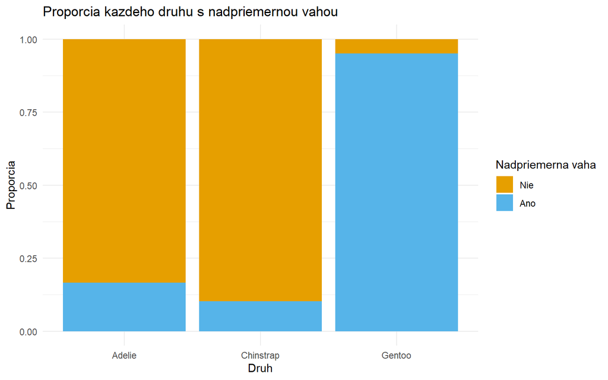

```r
ggplot(penguins %>% drop_na(above_average_weight),
       aes(fill = above_average_weight, x = species)) +
  geom_bar(position = "fill") +
  labs(title = "Proporcia kazdeho druhu s nadpriemernou vahou",
       x = "Druh",
       y = "Proporcia",
       fill = "Nadpriemerna vaha") +
  scale_fill_manual(values = c("0" = "#E69F00", "1" = "#56B4E9"),
                    labels = c("0" = "Nie", "1" = "Ano")) +
  theme_minimal()
```

Z grafu vidime, ze tucniaky Chinstrap su **najpravdepodobnejsie s podpriemernou vahou**. Avsak Chinstrap je **najzriedkavejsi druh** v prirode!

### 2.1.2 Bayesovo pravidlo pre klasifikaciu

Naive Bayes klasifikacia je priamou aplikaciou Bayesovho pravidla. Na vypocet posteriornej pravdepodobnosti, ze nas tucniak je druh $Y = y$ vzhladom na jeho stav vahy $X_1 = x_1$:

$$f(y \; | \; x_1) = \frac{\text{prior}
\cdot \text{likelihood}}{\text{normalizacna konstanta}} = \frac{f(y)L(y
\; | \; x_1)}{f(x_1)}$$

$$f(x_1) = \sum_{\text{vsetky } y'}
f(y')L(y' \; | \; x_1)$$

### 2.1.3 Vypocet z dat

```r
# Tabulka stavu vahy podla druhu
penguins %>%
  select(species, above_average_weight) %>%
  na.omit() %>%
  tabyl(species, above_average_weight) %>%
  adorn_totals(c("row", "col"))
```

```
##    species   0   1 Total
##     Adelie 126  25   151
##  Chinstrap  61   7    68
##     Gentoo   6 117   123
##      Total 193 149   342
```

### 2.1.4 Priorne pravdepodobnosti

```
## Prior pravdepodobnosti:
```

```
## P(Adelie) = 0.4415
```

```
## P(Chinstrap) = 0.1988
```

```
## P(Gentoo) = 0.3596
```

Z tabulky mozeme odvodit:

$f(y = A) = \frac{151}{342}$ = 0.4415

$$f(y = C) = \frac{68}{342}, \quad f(y =
G) = \frac{123}{342}$$

### 2.1.5 Likelihood

Likelihood ukazuje, ze podpriemerna vaha je **najcastejsia medzi Chinstrap** tucniakmi:

$$\begin{split}
L(y = A \; | \; x_1 = 0) & = \frac{126}{151} \approx 0.8344 \\
L(y = C \; | \; x_1 = 0) & = \frac{61}{68} \approx 0.8971 \\
L(y = G \; | \; x_1 = 0) & = \frac{6}{123} \approx 0.0488
\end{split}$$

```r
# Likelihood pre podpriemernu vahu
L_A <- 126/151
L_C <- 61/68
L_G <- 6/123

cat("Likelihoods L(y | x1 = 0):\n")
```

```
## Likelihoods L(y | x1 = 0):
```

```r
cat("L(Adelie | podpriemerna vaha) =", round(L_A, 4), "\n")
```

```
## L(Adelie | podpriemerna vaha) = 0.8344
```

```r
cat("L(Chinstrap | podpriemerna vaha) =", round(L_C, 4), "\n")
```

```
## L(Chinstrap | podpriemerna vaha) = 0.8971
```

```r
cat("L(Gentoo | podpriemerna vaha) =", round(L_G, 4), "\n")
```

```
## L(Gentoo | podpriemerna vaha) = 0.0488
```

### 2.1.6 Marginalna pravdepodobnost

$$f(x_1 = 0) = \frac{151}{342} \cdot
\frac{126}{151} + \frac{68}{342} \cdot \frac{61}{68} + \frac{123}{342}
\cdot \frac{6}{123} = \frac{193}{342}$$

```r
# Marginalna pravdepodobnost
marginal <- prior_A * L_A + prior_C * L_C + prior_G * L_G
cat("Marginalna pravdepodobnost f(x1 = 0) =", round(marginal, 4), "\n")
```

```
## Marginalna pravdepodobnost f(x1 = 0) = 0.5643
```

### 2.1.7 Posteriorna pravdepodobnost

$$f(y = A \; | \; x_1 = 0) = \frac{f(y =
A) \cdot L(y = A \; | \; x_1 = 0)}{f(x_1 = 0)} = \frac{(151/342) \cdot
(126/151)}{193/342} \approx 0.6528$$

```r
# Posteriorne pravdepodobnosti
post_A <- (prior_A * L_A) / marginal
post_C <- (prior_C * L_C) / marginal
post_G <- (prior_G * L_G) / marginal

cat("Posteriorne pravdepodobnosti:\n")
```

```
## Posteriorne pravdepodobnosti:
```

```r
cat("P(Adelie | podpriemerna vaha) =", round(post_A, 4), "\n")
```

```
## P(Adelie | podpriemerna vaha) = 0.6528
```

```r
cat("P(Chinstrap | podpriemerna vaha) =", round(post_C, 4), "\n")
```

```
## P(Chinstrap | podpriemerna vaha) = 0.3161
```

```r
cat("P(Gentoo | podpriemerna vaha) =", round(post_G, 4), "\n")
```

```
## P(Gentoo | podpriemerna vaha) = 0.0311
```

**Zaver**: Na zaklade informacie o podpriemernej vahe klasifikujeme tucniaka ako **Adelie**. Hoci podpriemerna vaha je relativne menej casta medzi Adelie ako medzi Chinstrap, finalna klasifikacia bola ovplyvnena tym, ze **Adelie su ovela beznejsie** v prirode.

## 2.2 Jeden kvantitativny prediktor

Teraz ignorujme vahu tucniaka a klasifikujme jeho druh **iba na zaklade toho, ze ma 50mm dlhy zobak**.

### 2.2.1 Vizualizacia hustot

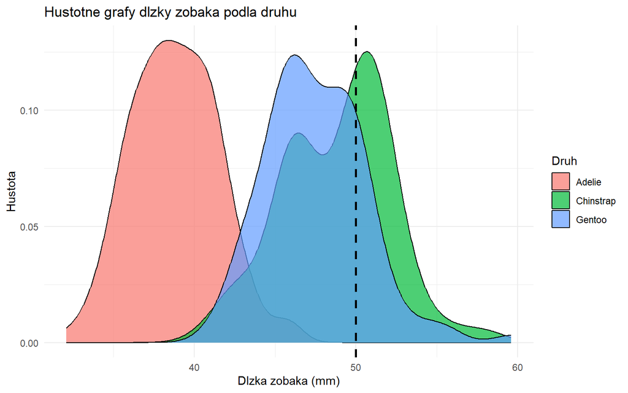

```r
ggplot(penguins, aes(x = bill_length_mm, fill = species)) +
  geom_density(alpha = 0.7) +
  geom_vline(xintercept = 50, linetype = "dashed", size = 1) +
  labs(title = "Hustotne grafy dlzky zobaka podla druhu",
       x = "Dlzka zobaka (mm)",
       y = "Hustota",
       fill = "Druh") +
  theme_minimal()
```

Z grafu vidime, ze 50mm dlhy zobak by bol **extremne dlhy pre Adelie**. Medzi Chinstrap a Gentoo je rozdiel menej dramaticky, ale Chinstrap zobaky maju tendenciu byt o nieco dlhsie.

### 2.2.2 Normalita ako “naivny” predpoklad

Tu prichadza **“naivna” cast** Naive Bayes klasifikacie. Metoda typicky predpoklada, ze akykolvek kvantitativny prediktor je **podmienene normalny**:

$$\begin{split}
X_2 \; | \; (Y = A) & \sim N(\mu_A, \sigma_A^2) \\
X_2 \; | \; (Y = C) & \sim N(\mu_C, \sigma_C^2) \\
X_2 \; | \; (Y = G) & \sim N(\mu_G, \sigma_G^2)
\end{split}$$

### 2.2.3 Odhad parametrov

```r
# Vypocet vyberovych priemerov a standardnych odchylok pre kazdy druh
bill_stats <- penguins %>%
  group_by(species) %>%
  summarize(mean = mean(bill_length_mm, na.rm = TRUE),
            sd = sd(bill_length_mm, na.rm = TRUE))

bill_stats
```

```
## # A tibble: 3 × 3
##   species    mean    sd
##   <fct>     <dbl> <dbl>
## 1 Adelie     38.8  2.66
## 2 Chinstrap  48.8  3.34
## 3 Gentoo     47.5  3.08
```

### 2.2.4 Normalne modely pre kazdy druh

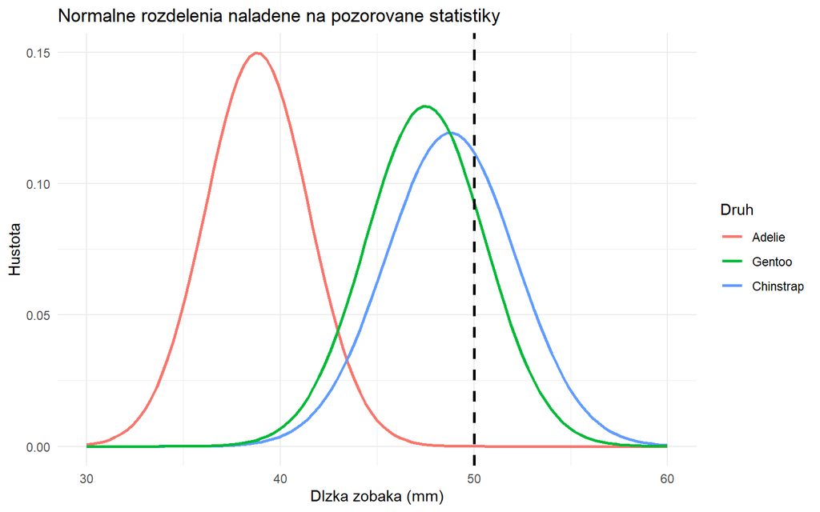

```r
ggplot(penguins, aes(x = bill_length_mm, color = species)) +
  stat_function(fun = dnorm, args = list(mean = 38.8, sd = 2.66),
                aes(color = "Adelie"), size = 1) +
  stat_function(fun = dnorm, args = list(mean = 48.8, sd = 3.34),
                aes(color = "Chinstrap"), size = 1) +
  stat_function(fun = dnorm, args = list(mean = 47.5, sd = 3.08),
                aes(color = "Gentoo"), size = 1) +
  geom_vline(xintercept = 50, linetype = "dashed", size = 1) +
  labs(title = "Normalne rozdelenia naladene na pozorovane statistiky",
       x = "Dlzka zobaka (mm)",
       y = "Hustota",
       color = "Druh") +
  xlim(30, 60) +
  theme_minimal()
```

### 2.2.5 Vypocet likelihood pomocou normalneho rozdelenia

Likelihood odpovedaju **vyskam normalnych kriviek** pri dlzke zobaka 50mm:

```r
# Likelihood pre 50mm zobak
L_A_bill <- dnorm(50, mean = 38.8, sd = 2.66)
L_C_bill <- dnorm(50, mean = 48.8, sd = 3.34)
L_G_bill <- dnorm(50, mean = 47.5, sd = 3.08)

cat("Likelihoods L(y | x2 = 50):\n")
```

```
## Likelihoods L(y | x2 = 50):
```

```r
cat("L(Adelie | zobak 50mm) =", format(L_A_bill, scientific = TRUE), "\n")
```

```
## L(Adelie | zobak 50mm) = 2.119955e-05
```

```r
cat("L(Chinstrap | zobak 50mm) =", round(L_C_bill, 4), "\n")
```

```
## L(Chinstrap | zobak 50mm) = 0.112
```

```r
cat("L(Gentoo | zobak 50mm) =", round(L_G_bill, 4), "\n")
```

```
## L(Gentoo | zobak 50mm) = 0.0932
```

### 2.2.6 Bayesovo pravidlo

$$f(y \; | \; x_2) = \frac{f(y)L(y \; | \;
x_2)}{f(x_2)} = \frac{f(y)L(y \; | \; x_2)}{\sum_{\text{vsetky } y'}
f(y')L(y' \; | \; x_2)}$$

```r
# Marginalna pravdepodobnost
marginal_bill <- prior_A * L_A_bill + prior_C * L_C_bill + prior_G * L_G_bill

# Posteriorne pravdepodobnosti
post_A_bill <- (prior_A * L_A_bill) / marginal_bill
post_C_bill <- (prior_C * L_C_bill) / marginal_bill
post_G_bill <- (prior_G * L_G_bill) / marginal_bill

cat("Posteriorne pravdepodobnosti (na zaklade dlzky zobaka):\n")
```

```
## Posteriorne pravdepodobnosti (na zaklade dlzky zobaka):
```

```r
cat("P(Adelie | zobak 50mm) =", round(post_A_bill, 4), "\n")
```

```
## P(Adelie | zobak 50mm) = 2e-04
```

```r
cat("P(Chinstrap | zobak 50mm) =", round(post_C_bill, 4), "\n")
```

```
## P(Chinstrap | zobak 50mm) = 0.3991
```

```r
cat("P(Gentoo | zobak 50mm) =", round(post_G_bill, 4), "\n")
```

```
## P(Gentoo | zobak 50mm) = 0.6007
```

**Zaver**: Na zaklade dlzky zobaka klasifikujeme tucniaka ako **Gentoo** (najvyssia posteriorna pravdepodobnost). Hoci 50mm dlhy zobak je relativne menej bezny medzi Gentoo ako medzi Chinstrap, finalna klasifikacia bola ovplyvnena tym, ze **Gentoo su ovela beznejsie** v prirode ako Chinstrap.

## 2.3 Dva prediktory

Mame dve klasifikacie ktore si **odporuju**:

- Na zaklade vahy: **Adelie**
- Na zaklade dlzky zobaka: **Gentoo**

Tato nezhoda naznacuje, ze existuje priestor na zlepsenie. Namiesto spolahnutia sa na jeden prediktor mozeme **kombinovat viacere prediktory**.

### 2.3.1 Vizualizacia dvoch prediktorov osobitne

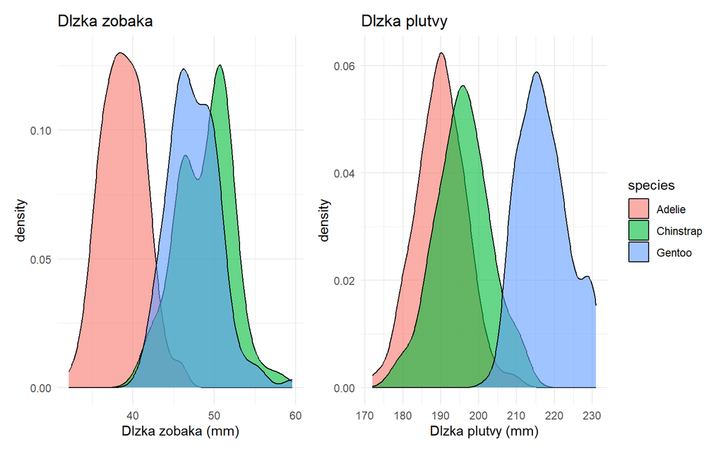

```r
library(patchwork)

p1 <- ggplot(penguins, aes(x = bill_length_mm, fill = species)) +
  geom_density(alpha = 0.6) +
  labs(title = "Dlzka zobaka", x = "Dlzka zobaka (mm)") +
  theme_minimal() +
  theme(legend.position = "none")

p2 <- ggplot(penguins, aes(x = flipper_length_mm, fill = species)) +
  geom_density(alpha = 0.6) +
  labs(title = "Dlzka plutvy", x = "Dlzka plutvy (mm)") +
  theme_minimal()

p1 + p2
```

### 2.3.2 Kombinacia prediktorov

Ked skombinujeme informacie o dlzke zobaka a plutvy, druhy su **dobre rozlisitelne**:

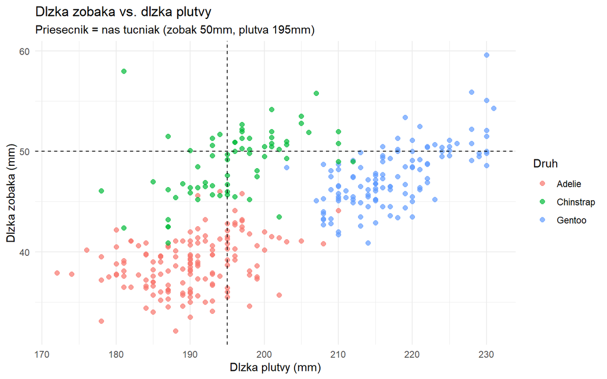

```r
ggplot(penguins, aes(x = flipper_length_mm, y = bill_length_mm, color = species)) +
  geom_point(alpha = 0.7, size = 2) +
  geom_vline(xintercept = 195, linetype = "dashed") +
  geom_hline(yintercept = 50, linetype = "dashed") +
  labs(title = "Dlzka zobaka vs. dlzka plutvy",
       subtitle = "Priesecnik = nas tucniak (zobak 50mm, plutva 195mm)",
       x = "Dlzka plutvy (mm)",
       y = "Dlzka zobaka (mm)",
       color = "Druh") +
  theme_minimal()
```

Nas tucniak s 50mm zobákom a 195mm plutvou lezi **jasne medzi pozorovaniami Chinstrap**!

### 2.3.3 Bayesovo pravidlo s dvoma prediktormi

$$f(y \; | \; x_2, x_3) = \frac{f(y) L(y
\; | \; x_2, x_3)}{\sum_{\text{vsetky } y'} f(y')L(y' \; |
\; x_2, x_3)}$$

### 2.3.4 Predpoklad podmienene nezavislosti

Tu prichadza dalsi **“naivny” predpoklad**. Naive Bayes klasifikacia predpoklada, ze prediktory su **podmienene nezavisle**:

$$L(y \; | \; x_2, x_3) = f(x_2, x_3 \; |
\; y) = f(x_2 \; | \; y) \cdot f(x_3 \; | \; y)$$

V slovach: **v ramci kazdeho druhu predpokladame, ze dlzka zobaka tucniaka nema ziadny vztah k dlzke jeho plutvy**.

Matematicky a vypoctovo tento predpoklad robi Naive Bayes algoritmus **efektivnym a zvladnutelnym**. Avsak moze ho aj **pokazit** - v skutocnosti su tieto premenne pozitivne korelovanene v ramci kazdeho druhu.

### 2.3.5 Normalne modely pre dlzku plutvy

```r
# Vypocet statistik pre dlzku plutvy
flipper_stats <- penguins %>%
  group_by(species) %>%
  summarize(mean = mean(flipper_length_mm, na.rm = TRUE),
            sd = sd(flipper_length_mm, na.rm = TRUE))

flipper_stats
```

```
## # A tibble: 3 × 3
##   species    mean    sd
##   <fct>     <dbl> <dbl>
## 1 Adelie     190.  6.54
## 2 Chinstrap  196.  7.13
## 3 Gentoo     217.  6.48
```

### 2.3.6 Vypocet likelihoodov

```r
# Likelihood pre dlzku plutvy 195mm
L_A_flipper <- dnorm(195, mean = 190, sd = 6.54)
L_C_flipper <- dnorm(195, mean = 196, sd = 7.13)
L_G_flipper <- dnorm(195, mean = 217, sd = 6.48)

cat("Likelihoods L(y | x3 = 195):\n")
```

```
## Likelihoods L(y | x3 = 195):
```

```r
cat("L(Adelie | plutva 195mm) =", round(L_A_flipper, 4), "\n")
```

```
## L(Adelie | plutva 195mm) = 0.0455
```

```r
cat("L(Chinstrap | plutva 195mm) =", round(L_C_flipper, 4), "\n")
```

```
## L(Chinstrap | plutva 195mm) = 0.0554
```

```r
cat("L(Gentoo | plutva 195mm) =", round(L_G_flipper, 6), "\n")
```

```
## L(Gentoo | plutva 195mm) = 0.000193
```

### 2.3.7 Kombinovane likelihoods

$$L(y \; | \; x_2 = 50, x_3 = 195) = L(y
\; | \; x_2 = 50) \cdot L(y \; | \; x_3 = 195)$$

```r
# Kombinovane likelihoods (predpoklad nezavislosti)
L_A_comb <- L_A_bill * L_A_flipper
L_C_comb <- L_C_bill * L_C_flipper
L_G_comb <- L_G_bill * L_G_flipper

cat("Kombinovane likelihoods:\n")
```

```
## Kombinovane likelihoods:
```

```r
cat("L(Adelie | zobak 50mm, plutva 195mm) =", format(L_A_comb, scientific = TRUE), "\n")
```

```
## L(Adelie | zobak 50mm, plutva 195mm) = 9.654647e-07
```

```r
cat("L(Chinstrap | zobak 50mm, plutva 195mm) =", format(L_C_comb, scientific = TRUE), "\n")
```

```
## L(Chinstrap | zobak 50mm, plutva 195mm) = 6.204155e-03
```

```r
cat("L(Gentoo | zobak 50mm, plutva 195mm) =", format(L_G_comb, scientific = TRUE), "\n")
```

```
## L(Gentoo | zobak 50mm, plutva 195mm) = 1.801748e-05
```

### 2.3.8 Finalna posteriorna pravdepodobnost

```r
# Vazenene likelihoods
weighted_A <- prior_A * L_A_comb
weighted_C <- prior_C * L_C_comb
weighted_G <- prior_G * L_G_comb

# Marginalna pravdepodobnost
marginal_comb <- weighted_A + weighted_C + weighted_G

# Posteriorne pravdepodobnosti
post_A_comb <- weighted_A / marginal_comb
post_C_comb <- weighted_C / marginal_comb
post_G_comb <- weighted_G / marginal_comb

cat("Finalne posteriorne pravdepodobnosti:\n")
```

```
## Finalne posteriorne pravdepodobnosti:
```

```r
cat("P(Adelie | zobak 50mm, plutva 195mm) =", round(post_A_comb, 4), "\n")
```

```
## P(Adelie | zobak 50mm, plutva 195mm) = 3e-04
```

```r
cat("P(Chinstrap | zobak 50mm, plutva 195mm) =", round(post_C_comb, 4), "\n")
```

```
## P(Chinstrap | zobak 50mm, plutva 195mm) = 0.9944
```

```r
cat("P(Gentoo | zobak 50mm, plutva 195mm) =", round(post_G_comb, 4), "\n")
```

```
## P(Gentoo | zobak 50mm, plutva 195mm) = 0.0052
```

**Zaver**: Nas tucniak je **takmer urcite Chinstrap** (posteriorna pravdepodobnost > 99%). Hoci sme neprisli k tomuto zaveru pouzitim ziadnej fyzickej charakteristiky samostatne, **spolocne maľuju jasny obraz**.

# 3 Formalna definicia Naive Bayes klasifikacie

Nech $Y$ oznacuje kategoricku odpovednu premennu s dvoma alebo viac kategoriami a $(X_1, X_2, \dots, X_p)$ je mnozina $p$ moznych prediktorov $Y$. Potom **posteriorna pravdepodobnost**, ze novy pripad s pozorovanymi prediktormi $(X_1, X_2, \ldots, X_p) = (x_1, x_2, \ldots, x_p)$ patri do triedy $Y = y$ je:

$$\boxed{f(y | x_1, x_2, \ldots, x_p) =
\frac{f(y)L(y \; | \; x_1, x_2, \ldots, x_p)}{\sum_{\text{vsetky }
y' }f(y')L(y' \; | \; x_1, x_2, \ldots, x_p)}}$$

## 3.1 Naivne predpoklady

Naive Bayes klasifikacia robi nasledujuce **naivne predpoklady** o likelihood funkcii $Y$:

### 3.1.1 1. Podmienena nezavislost prediktorov

Prediktory $X_i$ su podmienene nezavisle:

$$L(y \; | \; x_1, x_2, \ldots, x_p) =
\prod_{i=1}^p f(x_i \; | \; y)$$

### 3.1.2 2. Kategoricke prediktory

Pre kategoricke prediktory $X_i$ je podmienena pmf:

$$f(x_i \; | \; y) = P(X_i = x_i \; | \; Y
= y)$$

odhadnuta **vyberovou proporciou** pozorovanich pripadov $Y = y$ pre ktore $X_i = x_i$.

### 3.1.3 3. Kvantitativne prediktory

Pre kvantitativne prediktory $X_i$ je podmienena pdf definovana **normalnym modelom**:

$$X_i | (Y = y) \sim N(\mu_{iy},
\sigma^2_{iy})$$

V ramci kazdej kategorie $Y = y$ predpokladame, ze $X_i$ je normalne rozdelene okolo nejakej strednej hodnoty $\mu_{iy}$ so standardnou odchylkou $\sigma_{iy}$. Tieto parametre odhadujeme **vyberovym priemerom a standardnou odchylkou**.

# 4 Implementacia a hodnotenie Naive Bayes klasifikacie

## 4.1 Pouzitie funkcie naiveBayes()

V R pouzivame funkciu `naiveBayes()` z balika `e1071`:

```r
# Model 1: iba dlzka zobaka
naive_model_1 <- naiveBayes(species ~ bill_length_mm, data = penguins)

# Model 2: dlzka zobaka + dlzka plutvy
naive_model_2 <- naiveBayes(species ~ bill_length_mm + flipper_length_mm,
                            data = penguins)
```

## 4.2 Klasifikacia naseho tucniaka

```r
# Definicia naseho tucniaka
our_penguin <- data.frame(
  bill_length_mm = 50,
  flipper_length_mm = 195
)

our_penguin
```

```
##   bill_length_mm flipper_length_mm
## 1             50               195
```

### 4.2.1 Model 1 (iba dlzka zobaka)

```r
# Posteriorne pravdepodobnosti
predict(naive_model_1, newdata = our_penguin, type = "raw")
```

```
##            Adelie Chinstrap    Gentoo
## [1,] 0.0001690279 0.3978306 0.6020004
```

```r
# Klasifikacia
predict(naive_model_1, newdata = our_penguin)
```

```
## [1] Gentoo
## Levels: Adelie Chinstrap Gentoo
```

**Vysledok**: Na zaklade dlzky zobaka je nas tucniak klasifikovany ako **Gentoo**.

### 4.2.2 Model 2 (dlzka zobaka + dlzka plutvy)

```r
# Posteriorne pravdepodobnosti
predict(naive_model_2, newdata = our_penguin, type = "raw")
```

```
##            Adelie Chinstrap      Gentoo
## [1,] 0.0003445688 0.9948681 0.004787365
```

```r
# Klasifikacia
predict(naive_model_2, newdata = our_penguin)
```

```
## [1] Chinstrap
## Levels: Adelie Chinstrap Gentoo
```

**Vysledok**: Ked vezmeme do uvahy obe merania, nas tucniak je klasifikovany ako **Chinstrap** (zhodne s nasim manualnym vypoctom!).

## 4.3 Hodnotenie presnosti klasifikacie

### 4.3.1 Pridanie klasifikacii k datam

```r
penguins <- penguins %>%
  mutate(class_1 = predict(naive_model_1, newdata = .),
         class_2 = predict(naive_model_2, newdata = .))
```

### 4.3.2 Nahodna vzorka tucniakov

```r
set.seed(84735)
penguins %>%
  sample_n(4) %>%
  select(bill_length_mm, flipper_length_mm, species, class_1, class_2) %>%
  rename(bill = bill_length_mm, flipper = flipper_length_mm)
```

```
## # A tibble: 4 × 5
##    bill flipper species   class_1 class_2
##   <dbl>   <int> <fct>     <fct>   <fct>
## 1  47.5     199 Chinstrap Gentoo  Chinstrap
## 2  40.9     214 Gentoo    Adelie  Gentoo
## 3  41.3     194 Adelie    Adelie  Adelie
## 4  38.5     190 Adelie    Adelie  Adelie
```

### 4.3.3 Confusion Matrix pre Model 1

```r
penguins %>%
  tabyl(species, class_1) %>%
  adorn_percentages("row") %>%
  adorn_pct_formatting(digits = 2) %>%
  adorn_ns()
```

```
##    species       Adelie Chinstrap       Gentoo
##     Adelie 95.39% (145) 0.00% (0)  4.61%   (7)
##  Chinstrap  5.88%   (4) 8.82% (6) 85.29%  (58)
##     Gentoo  6.45%   (8) 4.84% (6) 88.71% (110)
```

### 4.3.4 Confusion Matrix pre Model 2

```r
penguins %>%
  tabyl(species, class_2) %>%
  adorn_percentages("row") %>%
  adorn_pct_formatting(digits = 2) %>%
  adorn_ns()
```

```
##    species       Adelie   Chinstrap       Gentoo
##     Adelie 96.05% (146)  2.63%  (4)  1.32%   (2)
##  Chinstrap  7.35%   (5) 86.76% (59)  5.88%   (4)
##     Gentoo  0.81%   (1)  0.81%  (1) 98.39% (122)
```

### 4.3.5 Porovnanie modelov

```r
# Celkova presnost Model 1
correct_1 <- 145 + 6 + 110
total <- nrow(penguins %>% drop_na(class_1))
accuracy_1 <- correct_1 / total

# Celkova presnost Model 2
correct_2 <- 146 + 59 + 122
accuracy_2 <- correct_2 / total

cat("Celkova presnost:\n")
```

```
## Celkova presnost:
```

```r
cat("Model 1 (iba zobak):", round(accuracy_1 * 100, 1), "%\n")
```

```
## Model 1 (iba zobak): 75.9 %
```

```r
cat("Model 2 (zobak + plutva):", round(accuracy_2 * 100, 1), "%\n")
```

```
## Model 2 (zobak + plutva): 95.1 %
```

**Hlavne zistenia**:

1. **Model 2 je lepsi celkovo** (95% vs 76% presnost)
2. **Najvacsi rozdiel je v klasifikacii Chinstrap**: Model 1 spravne klasifikuje iba 9% Chinstrap (85% je nespravne klasifikovanych ako Gentoo), zatial co Model 2 spravne klasifikuje 87%
3. Model 2 ma vyssiu presnost pre **vsetky tri druhy**

## 4.4 Krizova validacia

Pre lepsiu predstavu o tom, ako dobre nase Naive Bayes modely klasifikuju **novych tucniakov** (nie iba tych v nasej vzorke), pouzijeme **10-fold krizovu validaciu**:

```r
set.seed(84735)
cv_model_2 <- naive_classification_summary_cv(
  model = naive_model_2, data = penguins, y = "species", k = 10)

# Krizovo validovana confusion matrix
cv_model_2$cv
```

[output not shown]

Miera presnosti v krizovo validovanej confusion matrix su **porovnatelne** s nekrizovo validovanou. To znamena, ze nas Naive Bayes model **funguje takmer rovnako dobre na novych tucniakoch** ako na povodnej vzorke.

# 5 Naive Bayes vs Logisticka regresia

## 5.1 Kedy pouzit Naive Bayes

V scenaroch s **binarnou kategorickou odpovednou premennou** $Y$ su oba pristupy zivotaschopne. Otazkou je, ktory nastroj pouzit.

## 5.2 Vyhody a nevyhody

| Aspekt | Naive Bayes | Logisticka regresia |
| --- | --- | --- |
| **Pocet kategorii** | 2+ kategorii | Iba 2 kategorie (standardne) |
| **Vypoctova efektivnost** | Velmi efektivny | Vyzaduje MCMC |
| **Predpoklady** | Rigidne (normalita, nezavislost) | Flexibilnejsie |
| **Interpretovatelnost** | Ziadne regresne koeficienty | Regresne koeficienty $\beta_i$ |
| **Vztahy medzi premennymi** | Nezobrazuje | Jasne ukazuje |

## 5.3 Kedy ktory pouzit?

- **Pouzite logisticku regresiu** ak:
  - Rigidne predpoklady Naive Bayes su nevhodne
  - Zaujimaju vas specificke spojenia medzi $Y$ a $X$
- **Pouzite Naive Bayes** ak:
  - Potrebujete rychlu klasifikaciu
  - Nestarate sa o interpretaciu koeficientov
  - Mate viac ako 2 kategorie

**Najlepsia rada**: Skuste oba! Ucte sa od oboch nastrojov.

# 6 Zhrnutie kapitoly

## 6.1 Hlavne body

1. **Naive Bayes klasifikacia** je uzitocny nastroj na klasifikaciu kategorickych odpovednych premennych $Y$ s dvoma alebo viac kategoriami.
2. **Bayesovo pravidlo** je jadrom metody:

$$f(y | x_1, x_2, \ldots, x_p) =
\frac{f(y)L(y \; | \; x_1, x_2, \ldots, x_p)}{\sum_{\text{vsetky }
y' }f(y')L(y' \; | \; x_1, x_2, \ldots, x_p)}$$

3. **Naivne predpoklady**:
   - Prediktory $X_i$ su **podmienene nezavisle**
   - Hodnoty kvantitativnych prediktorov sa menia **normalne** v ramci kazdej kategorie $Y = y$
4. **Ked su predpoklady splnene**: Tieto zjednodusujuce predpoklady robia Naive Bayes model vypoctovo efektivnym a jednoducho aplikovatelnym.
5. **Ked su predpoklady porusene** (co je bezne): Naive Bayes model moze produkovat **zavadzajuce klasifikacie**.

## 6.2 Klucove vzorce

| Koncept | Vzorec |
| --- | --- |
| Posteriorna pravdepodobnost | $f(y \\| x) = \frac{f(y)L(y\\|x)}{f(x)}$ |
| Podmienena nezavislost | $L(y \\| x_1, \ldots, x_p) = \prod_{i=1}^p f(x_i \\| y)$ |
| Normalny model | $X_i \\| (Y=y) \sim N(\mu_{iy}, \sigma^2_{iy})$ |

## 6.3 R funkcie

| Funkcia | Pouzitie |
| --- | --- |
| `naiveBayes()` | Vytvorenie Naive Bayes modelu |
| `predict()` | Klasifikacia novych pripadov |
| `naive_classification_summary_cv()` | Krizova validacia |